# Machine Learning - 1st assignment

Lior Ginzberg

Saturday, February 21, 2015

Instructions: The goal of your project is to predict the manner in which they did the exercise. This is the “classe” variable in the training set. You may use any of the other variables to predict with. You should create a report describing how you built your model, how you used cross validation, what you think the expected out of sample error is, and why you made the choices you did. You will also use your prediction model to predict 20 different test cases.

1. Your submission should consist of a link to a Github repo with your R markdown and compiled HTML file describing your analysis. Please constrain the text of the writeup to < 2000 words and the number of figures to be less than 5. It will make it easier for the graders if you submit a repo with a gh-pages branch so the HTML page can be viewed online (and you always want to make it easy on graders :-).
2. You should also apply your machine learning algorithm to the 20 test cases available in the test data above. Please submit your predictions in appropriate format to the programming assignment for automated grading. See the programming assignment for additional details.

The assignment starts by loading the train and test data sets

```r
library("caret")
```

```r
library("ggplot2")
#fileUrl <- "https://d396qusza40orc.cloudfront.net/predmachlearn/pml-training.csv"
#download.file(fileUrl, destfile = "C:\\Personal\\Coursera\\Machine learning\\project\\training.csv")

training <- read.csv("C:\\Personal\\Coursera\\Machine learning\\project\\training.csv",
                       sep = ",", header = TRUE, blank.lines.skip = TRUE, na.strings = c("NA", ""))

#fileUrl <- "https://d396qusza40orc.cloudfront.net/predmachlearn/pml-testing.csv"
#download.file(fileUrl, destfile = "C:\\Personal\\Coursera\\Machine learning\\project\\test.csv")

testing <- read.csv("C:\\Personal\\Coursera\\Machine learning\\project\\test.csv",
                      sep = ",", header = TRUE, blank.lines.skip = TRUE, na.strings = c("NA", ""))
```

By running the summary command on the training data set it is apparent that many of the columns in both data sets contain high number of NA values. Clean the data by removing the relevant columns from the training and testing sets.

```r
#summary(training)
NAs <- apply(training, 2, function(x) {
  sum(is.na(x))
})
training <- training[, which(NAs == 0)]
testing <- testing[, which(NAs == 0)]
```

Once the data is clean the next step would be to split the training data set to sub testing and training sets to improve the performance of the random forest prediction model.

```r
inTrain <- createDataPartition(y=training$classe,p=0.25, list=FALSE)
training_train <- training[inTrain,]
training_test <- training[-inTrain,]
```

Once the training data set has been split, run the random forest prediction model. This model was selected due to its high accuracy level.

```r
modFit <- train(classe~ .,data=training_train,method="rf",prox=TRUE)
#modFit
print(modFit$finalModel)
```

```
##
## Call:
##  randomForest(x = x, y = y, mtry = param$mtry, proximity = TRUE)
##                Type of random forest: classification
##                      Number of trees: 500
## No. of variables tried at each split: 41
##
##         OOB estimate of  error rate: 0.02%
## Confusion matrix:
##      A   B   C   D   E class.error
## A 1395   0   0   0   0    0.000000
## B    0 950   0   0   0    0.000000
## C    0   0 856   0   0    0.000000
## D    0   0   0 804   0    0.000000
## E    0   0   0   1 901    0.001109
```

As you can see from the output of the modFit$finalModel command the expected accuracy of the model is very high. As first trial of the prediction model apply the prediction model on the test sub data set, plot the result and check its accuracy level.

```r
pred <- predict(modFit,training_test)
training_test$predRight <- pred == training_test$classe
table(pred,training_test$classe)
```

```
##
## pred    A    B    C    D    E
##    A 4185    1    0    0    0
##    B    0 2841    0    0    0
##    C    0    5 2566    0    0
##    D    0    0    0 2412    0
##    E    0    0    0    0 2705
```

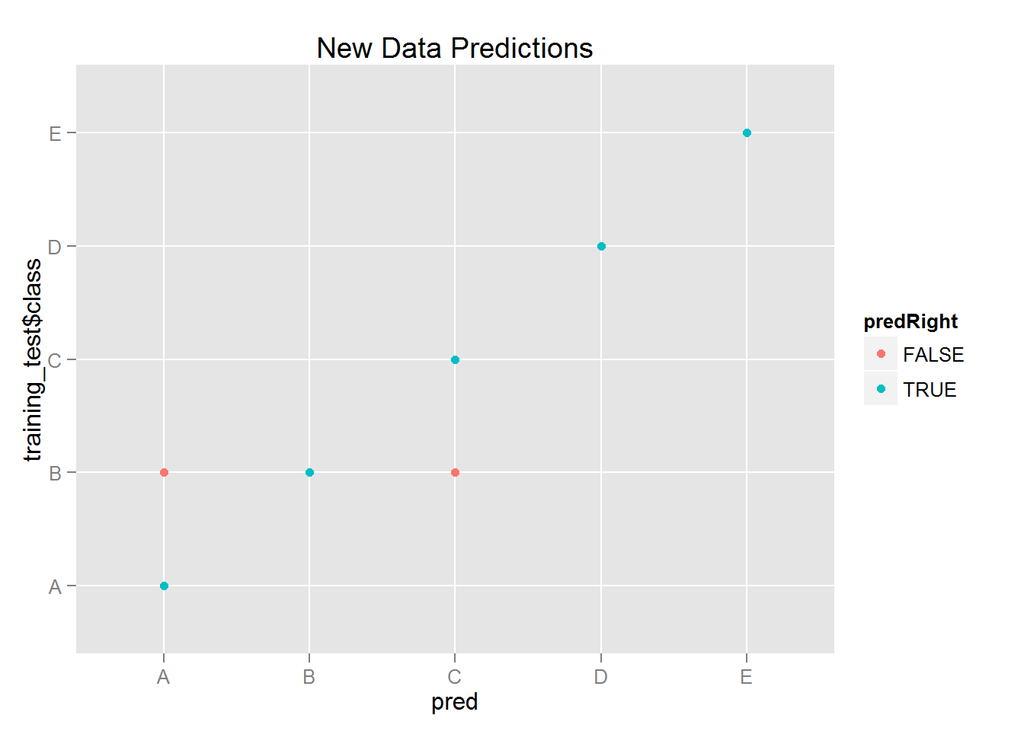

```r
qplot(pred,training_test$class,colour=predRight,data=training_test,main="New Data Predictions")
```

```r
confusionMatrix(pred, training_test$classe)
```

```
## Confusion Matrix and Statistics
##
##           Reference
## Prediction    A    B    C    D    E
##          A 4185    1    0    0    0
##          B    0 2841    0    0    0
##          C    0    5 2566    0    0
##          D    0    0    0 2412    0
##          E    0    0    0    0 2705
##
## Overall Statistics
##
##                Accuracy : 1
##                  95% CI : (0.999, 1)
##     No Information Rate : 0.284
##     P-Value [Acc > NIR] : <2e-16
##
##                   Kappa : 0.999
##  Mcnemar's Test P-Value : NA
##
## Statistics by Class:
##
##                      Class: A Class: B Class: C Class: D Class: E
## Sensitivity             1.000    0.998    1.000    1.000    1.000
## Specificity             1.000    1.000    1.000    1.000    1.000
## Pos Pred Value          1.000    1.000    0.998    1.000    1.000
## Neg Pred Value          1.000    0.999    1.000    1.000    1.000
## Prevalence              0.284    0.193    0.174    0.164    0.184
## Detection Rate          0.284    0.193    0.174    0.164    0.184
## Detection Prevalence    0.284    0.193    0.175    0.164    0.184
## Balanced Accuracy       1.000    0.999    1.000    1.000    1.000
```

As the final trial apply the prediction model on the original testing data set (20 records) and append the data set with the predicted value of the classe column.

```r
pred_test <- predict(modFit,testing)
testing$classe <- pred_test
table(pred_test,testing$classe)
```

```
##
## pred_test  A  B  C  D  E
##         A 20  0  0  0  0
##         B  0  0  0  0  0
##         C  0  0  0  0  0
##         D  0  0  0  0  0
##         E  0  0  0  0  0
```